# 135_Project3

Richard Ly

2/27/2022

# Introduction

We will study the undergraduate grade point average (`GPA`) and graduate management aptitude test (`GMAT`) scores of students from three schools. The question of interest is whether the mean `GPA` and mean `GMAT` scores differ between the three schools.

In the Material and Methods section, we list the formulas used to arrive at a conclusion; Included in this section is EDA performed on the dataset. MANOVA is used to perform hypothesis testing. Simultaneous confidence intervals are constructed.

In the Results section, the results from the Materials and Methods section are summarized. Outputs from the Materials and Methods section are used to explain the final results.

# Material and Methods

## Dataset

The `Project_3_Data` dataset contains two columns of data: `GPA` and `GMAT` giving $p=2$. The dataset contains 1 column as a factor: `SCHOOL` with 3 levels giving $g=3$. There are 85 observations.

## Exploratory Data Analysis

1. Summary Statistics

```r
summary(Project_3_Data$GPA)
```

```
##    Min. 1st Qu.  Median    Mean 3rd Qu.    Max.
##   2.130   2.600   3.010   2.975   3.300   3.800
```

```r
summary(Project_3_Data$GMAT)
```

```
##    Min. 1st Qu.  Median    Mean 3rd Qu.    Max.
##   313.0   425.0   482.0   488.4   538.0   693.0
```

2. Graphics

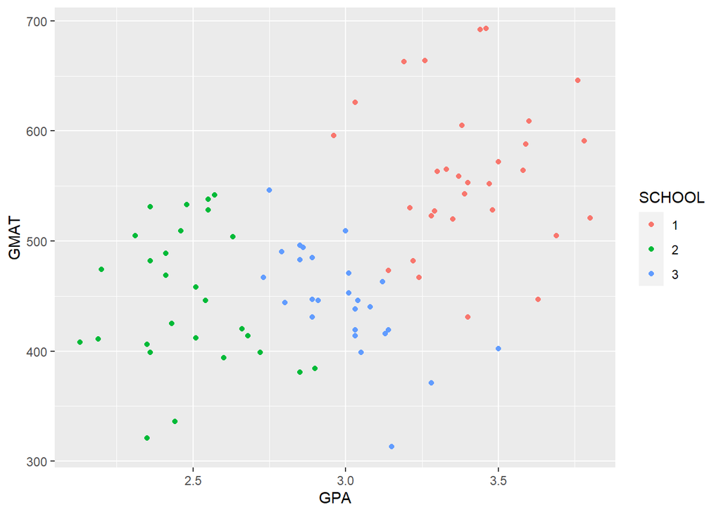

```r
ggplot(Project_3_Data, aes(x = GPA, y = GMAT, color = SCHOOL)) + geom_point()
```

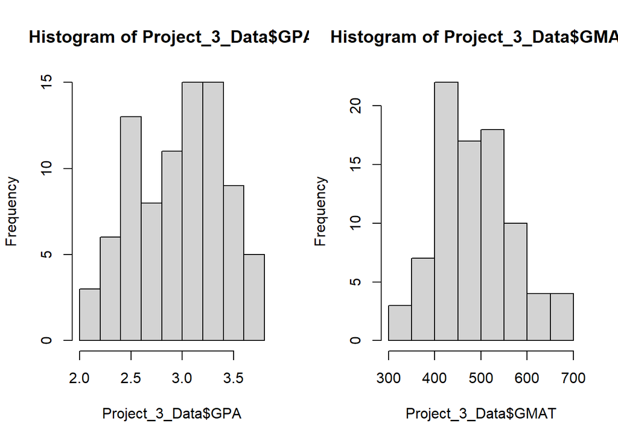

```r
par(mfrow=c(1,2))
hist(Project_3_Data$GPA)
hist(Project_3_Data$GMAT)
```

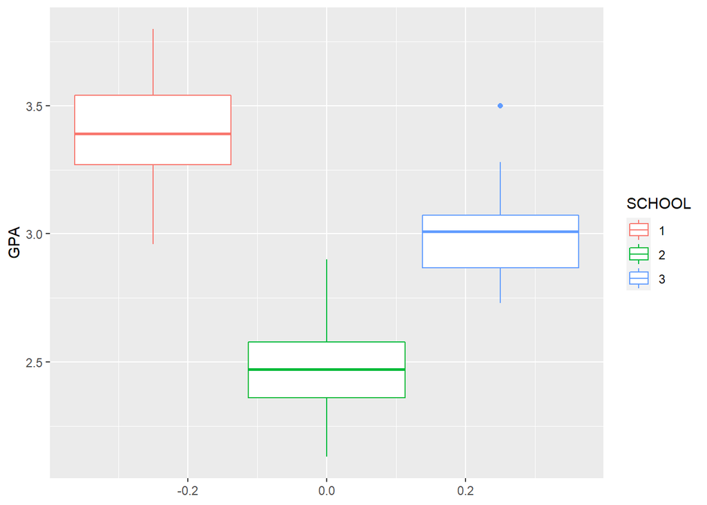

```r
ggplot(Project_3_Data, aes(y = GPA, color = SCHOOL)) + geom_boxplot()
```

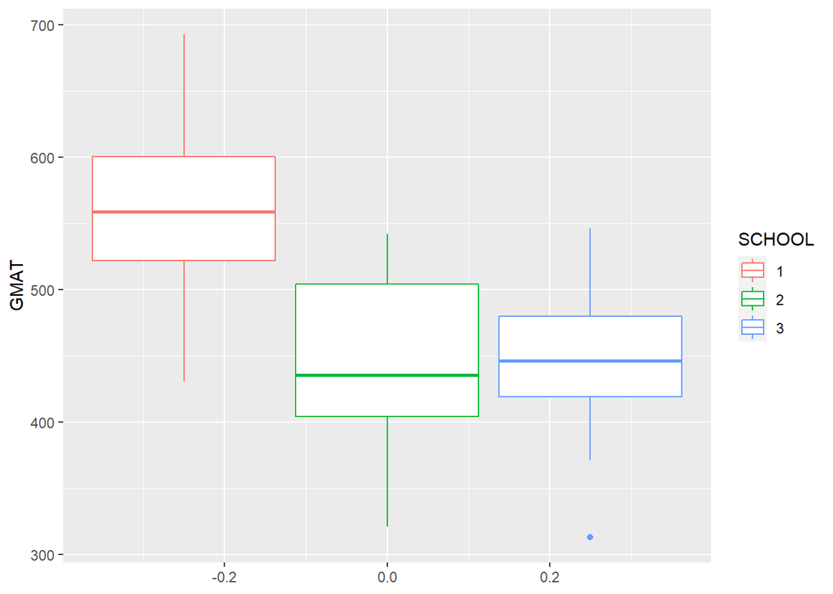

```r
ggplot(Project_3_Data, aes(y = GMAT, color = SCHOOL)) + geom_boxplot()
```

## Hypothesis Testing

$H_0 : \tau_1 = \tau_2 = \tau_3 = 0$ vs $H_a: \tau_j \neq 0$ for some $j$

We reject $H_0$ at level $\alpha = 0.05$ if:

$- (n_T - 1 - \frac{p+g}{2})\text{log}\Lambda^* > \chi^2_{p(g-1)}(\alpha)$

where:

- $n_T = n_1 + n_2 + n_3$ is the total number of observations and $n_\ell$ is the number of observations for school $\ell$
- $\Lambda^* = \frac{|SSR|}{|SSR + SST|}$ is the Wilks statistic
- and we call $(n_T - 1 - \frac{p+g}{2})\text{log}\Lambda^*$ the Bartlett value

```r
wilks_stats
```

```
## [1] 0.1263766
```

```r
bartlett_val
```

```
## [1] 168.5818
```

```r
critical_value
```

```
## [1] 9.487729
```

```r
bartlett_val > critical_value
```

```
## [1] TRUE
```

Since the Bartlett value is greater than the critical value, we reject the null hypothesis $H_0$ and conclude the alternative hypothesis $H_a$.

## Simultaneous Confidence Intervals

We create 95% simultaneous confidence intervals such that $\alpha = 0.05$.

$\overline{X}_{ki} - \overline{X}_{\ell i} \pm t_{df}(\frac{\alpha}{pg(g-1)})\sqrt{(\frac{1}{n_k} +\frac{1}{n_\ell})\frac{SSR_{ii}}{df}}$

```r
SCI
```

```
## $school1.school2
##           GPA      GMAT
## L12 0.7874969  71.53245
## U12 1.0552451 156.77630
##
## $school1.school3
##           GPA      GMAT
## L13 0.2746259  71.52031
## U13 0.5477314 158.46976
##
## $school2.school3
##            GPA      GMAT
## L23 -0.6500420 -43.68374
## U23 -0.3703426  45.36506
```

We note that among the simultaneous confidence intervals, there are confidence intervals not containing 0.

# Results

From hypothesis testing, we can conclude with 95% confidence that the mean `GPA` and mean `GMAT` scores from the three schools are not equivalent. The Bartlett value was found to be greater than the critical value, and so the null hypothesis was rejected: the factor effects $\tau_i$ are not all 0. Consequently, the mean `GPA` and mean `GMAT` scores are not equal.

From constructing 95% simultaneous confidence intervals, lower and upper bounds were found for pairs of the three schools. Since 0 is not included in every confidence interval, we reject $H_0$ at level $\alpha = 0.05$. This is consistent with the hypothesis testing.

# Appendix

```r
Project_3_Data <- read.csv("C:/Users/rly75/OneDrive/Desktop/135/Projects/Project_3_Data.txt", sep="")
Project_3_Data$SCHOOL = as.factor(Project_3_Data$SCHOOL)
```

```r
library(ggplot2)

summary(Project_3_Data$GPA)
```

```
##    Min. 1st Qu.  Median    Mean 3rd Qu.    Max.
##   2.130   2.600   3.010   2.975   3.300   3.800
```

```r
summary(Project_3_Data$GMAT)
```

```
##    Min. 1st Qu.  Median    Mean 3rd Qu.    Max.
##   313.0   425.0   482.0   488.4   538.0   693.0
```

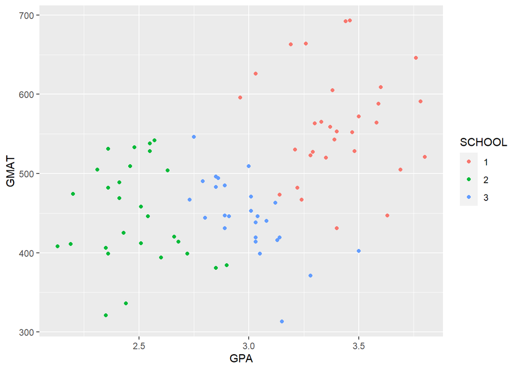

```r
ggplot(Project_3_Data, aes(x = GPA, y = GMAT, color = SCHOOL)) + geom_point()
```

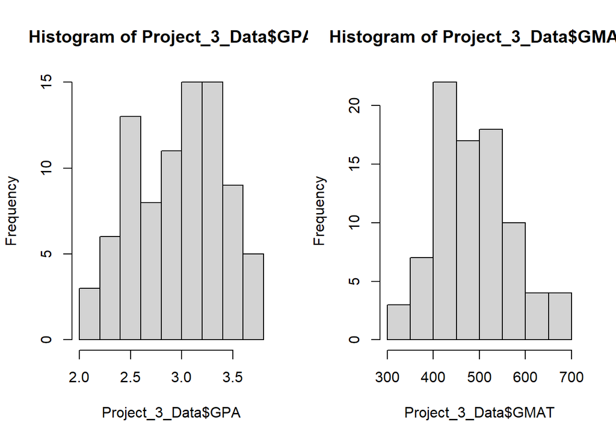

```r
par(mfrow=c(1,2))
hist(Project_3_Data$GPA)
hist(Project_3_Data$GMAT)
```

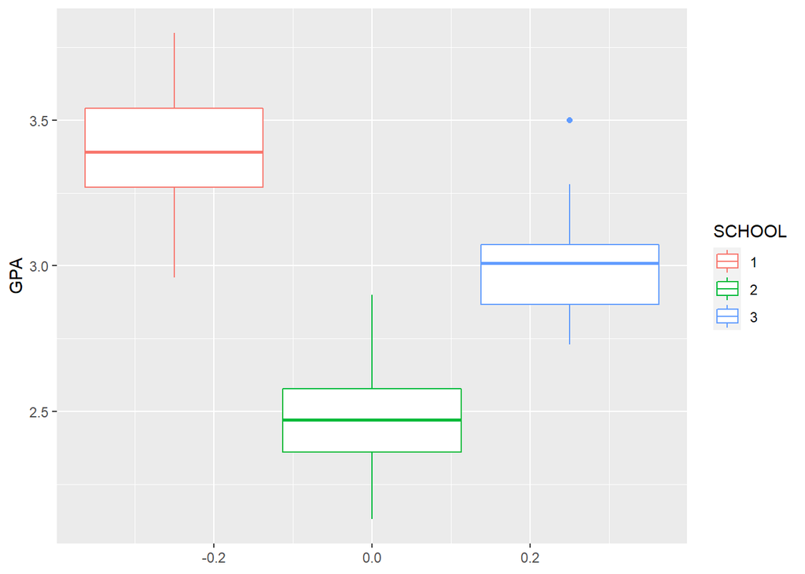

```r
ggplot(Project_3_Data, aes(y = GPA, color = SCHOOL)) + geom_boxplot()
```

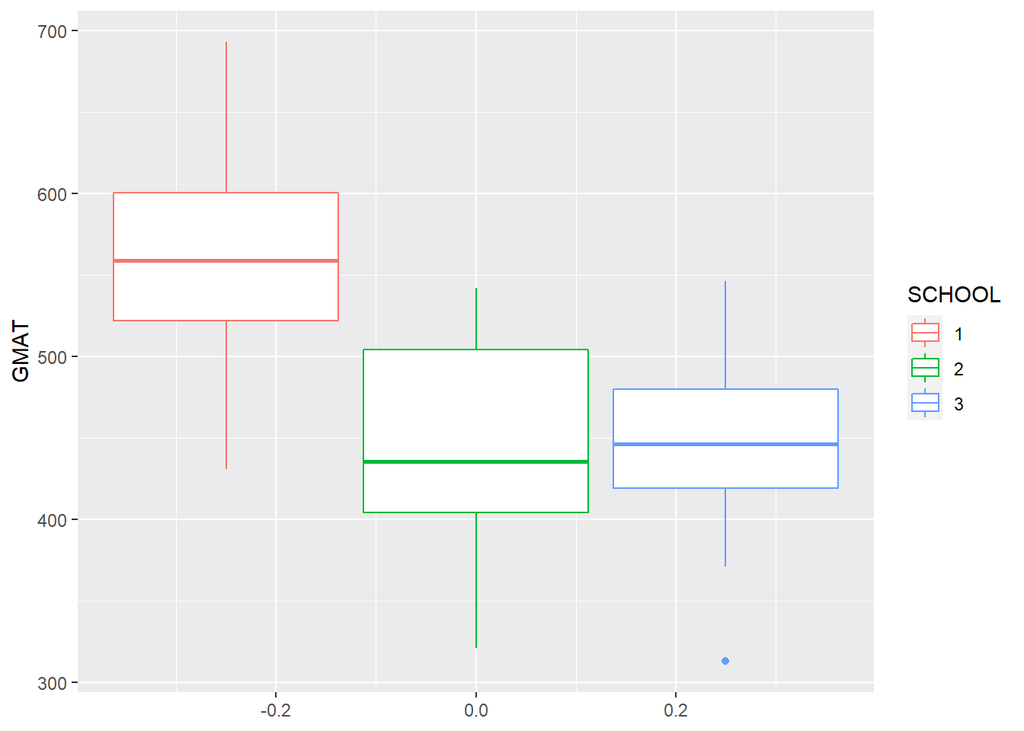

```r
ggplot(Project_3_Data, aes(y = GMAT, color = SCHOOL)) + geom_boxplot()
```

```r
p = ncol(Project_3_Data) - 1
scores = as.matrix(Project_3_Data[,1:p])
MANOVA_scores = manova(scores ~ Project_3_Data$SCHOOL)
summary.aov(MANOVA_scores)
```

```
##  Response GPA :
##                       Df  Sum Sq Mean Sq F value    Pr(>F)
## Project_3_Data$SCHOOL  2 12.5015  6.2508  173.31 < 2.2e-16 ***
## Residuals             82  2.9576  0.0361
## ---
## Signif. codes:  0 '***' 0.001 '**' 0.01 '*' 0.05 '.' 0.1 ' ' 1
##
##  Response GMAT :
##                       Df Sum Sq Mean Sq F value    Pr(>F)
## Project_3_Data$SCHOOL  2 258471  129236   35.35 8.492e-12 ***
## Residuals             82 299784    3656
## ---
## Signif. codes:  0 '***' 0.001 '**' 0.01 '*' 0.05 '.' 0.1 ' ' 1
```

```r
school1 = Project_3_Data[which(Project_3_Data[,p+1]=="1"), 1:p]
school2 = Project_3_Data[which(Project_3_Data[,p+1]=="2"), 1:p]
school3 = Project_3_Data[which(Project_3_Data[,p+1]=="3"), 1:p]

n1 = sum(Project_3_Data[,p+1] == "1")
n2 = sum(Project_3_Data[,p+1] == "2")
n3 = sum(Project_3_Data[,p+1] == "3")

SSR = (n1 - 1) * var(school1) + (n2 - 1) * var(school2) + (n3 - 1) * var(school3)
SST = n1 * tcrossprod(colMeans(school1) - colMeans(Project_3_Data[,1:p])) + n2 * tcrossprod(colMeans(school2) - colMeans(Project_3_Data[,1:p])) + n3 * tcrossprod(colMeans(school3) - colMeans(Project_3_Data[,1:p]))

wilks_stats = det(SSR) / det(SSR + SST)
wilks_stats
```

```
## [1] 0.1263766
```

```r
g = 3
n = n1 + n2 + n3
bartlett_val = - (n - 1 - (p+g)/2)*log(wilks_stats)
bartlett_val
```

```
## [1] 168.5818
```

```r
critical_value = qchisq(0.05,p*(g-1),lower.tail = FALSE)
bartlett_val > critical_value
```

```
## [1] TRUE
```

```r
alpha = 0.05

w_diag = diag(SSR)

L12 = colMeans(school1) - colMeans(school2) - qt(alpha/(p*g*(g-1)), n-g,lower.tail = FALSE)*sqrt(c(1/n1 + 1/n2)*w_diag/(n-g))

U12 = colMeans(school1) - colMeans(school2) + qt(alpha/(p*g*(g-1)), n-g,lower.tail = FALSE)*sqrt(c(1/n1 + 1/n2)*w_diag/(n-g))

L13 = colMeans(school1) - colMeans(school3) - qt(alpha/(p*g*(g-1)), n-g,lower.tail = FALSE)*sqrt(c(1/n1 + 1/n3)*w_diag/(n-g))

U13 = colMeans(school1) - colMeans(school3) + qt(alpha/(p*g*(g-1)), n-g,lower.tail = FALSE)*sqrt(c(1/n1 + 1/n3)*w_diag/(n-g))

L23 = colMeans(school2) - colMeans(school3) - qt(alpha/(p*g*(g-1)), n-g,lower.tail = FALSE)*sqrt(c(1/n2 + 1/n3)*w_diag/(n-g))

U23 = colMeans(school2) - colMeans(school3) + qt(alpha/(p*g*(g-1)), n-g,lower.tail = FALSE)*sqrt(c(1/n2 + 1/n3)*w_diag/(n-g))

SCI = list("school1.school2" = rbind(L12,U12), "school1.school3" = rbind(L13,U13),"school2.school3" = rbind(L23,U23))

SCI
```

```
## $school1.school2
##           GPA      GMAT
## L12 0.7874969  71.53245
## U12 1.0552451 156.77630
##
## $school1.school3
##           GPA      GMAT
## L13 0.2746259  71.52031
## U13 0.5477314 158.46976
##
## $school2.school3
##            GPA      GMAT
## L23 -0.6500420 -43.68374
## U23 -0.3703426  45.36506
```